# Ancient cities and inscriptions

In this exercise you will map the ancient equivalent of Twitter data: the ancient inscriptions. Ancient people of class, education, and means liked to advertise their achievements and life milestones as well as their sorrows via the means of texts inscribed in stone. These epigraphic monuments were often placed near inhabited areas, roads, and gathering places where they were likely to attract the largest audience. The location of these self-expressions in space and time is a reasonable indicator of changing economic prosperity of the commissioning communities. In this exercise, you will explore how these ancient inscriptions spatially correspond to the distribution of ancient cities and settlements.

# Task 1: Load ancient cities and convert to sf object

John Hanson has created a dataset of all cities in the ancient Mediterranean and made it available online. You will download this dataset and convert it into an sf object in order to compare with the inscriptions on the basis of location.

- Use `read_csv()` to load `Hanson2016_Cities_OxREP.csv` dataset from the provided URL and assign it to `cities` object

```r
cities <- as.data.frame(read_csv("http://oxrep.classics.ox.ac.uk/oxrep/docs/Hanson2016/Hanson2016_Cities_OxREP.csv"))
```

… then reproject this data to EPSG 3035

```r
# Convert the table into an sf object on the basis of X and Y columns
cities_sf <- st_as_sf(cities, coords = c("Longitude (X)", "Latitude (Y)"))

# Define the projection of Lat/Long coordinates as EPSG 4326
cities_sf4326 <- st_set_crs(cities_sf, 4326)

# Transform the projection to a 2D projection using EPSG 3035
cities_sf3035 <- st_transform(cities_sf4326, crs = 3035)

# Verify the projection is 'projected' not 'geographic'
st_crs(cities_sf3035)  # The output displays 'PROJCRS' meaning that the data has been projected
```

```
Coordinate Reference System:
  User input: EPSG:3035
  wkt:
PROJCRS["ETRS89-extended / LAEA Europe",
    BASEGEOGCRS["ETRS89",
        DATUM["European Terrestrial Reference System 1989",
            ELLIPSOID["GRS 1980",6378137,298.257222101,
                LENGTHUNIT["metre",1]]],
        PRIMEM["Greenwich",0,
            ANGLEUNIT["degree",0.0174532925199433]],
        ID["EPSG",4258]],
    CONVERSION["Europe Equal Area 2001",
        METHOD["Lambert Azimuthal Equal Area",
            ID["EPSG",9820]],
        PARAMETER["Latitude of natural origin",52,
            ANGLEUNIT["degree",0.0174532925199433],
            ID["EPSG",8801]],
        PARAMETER["Longitude of natural origin",10,
            ANGLEUNIT["degree",0.0174532925199433],
            ID["EPSG",8802]],
        PARAMETER["False easting",4321000,
            LENGTHUNIT["metre",1],
            ID["EPSG",8806]],
        PARAMETER["False northing",3210000,
            LENGTHUNIT["metre",1],
            ID["EPSG",8807]]],
    CS[Cartesian,2],
        AXIS["northing (Y)",north,
            ORDER[1],
            LENGTHUNIT["metre",1]],
        AXIS["easting (X)",east,
            ORDER[2],
            LENGTHUNIT["metre",1]],
    USAGE[
        SCOPE["unknown"],
        AREA["Europe - LCC & LAEA"],
        BBOX[24.6,-35.58,84.17,44.83]],
    ID["EPSG",3035]]
```

### Question 1:

*What are the measurement units of the `cities_sf3035` object?*

```r
st_crs(cities_sf3035)$units
```

```
[1] "m"
```

The measuring unit used in the object is *meters*

# Task 2: Create a buffer around each city and inspect the result

As each city and inscription corresponds to a dot on the map, the best way to grab and review the inscriptions will be by creating a buffer around each city point and then selecting inscriptions on the basis of that.

- Create a buffer around the projected `cities` geometry with `st_buffer()` , setting the `dist` argument to the desired radius of 5000m.
- Plot the resulting buffer with city on top for quick review.

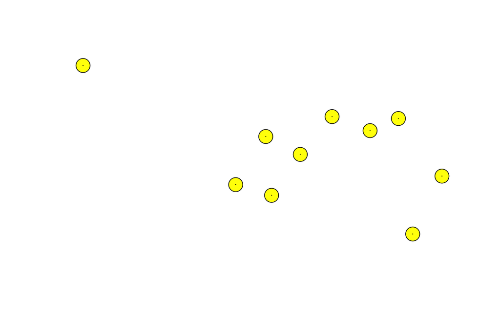

```r
# Make buffer of 5 km. Check the units of your object to correctly assign value to dist
cities_5km<- st_buffer(cities_sf3035, dist = 5000)

# Plot the first 10 buffers and cities to check result
# Ensure that plots are output to the console
plot(st_geometry(cities_5km)[1:10], col = "yellow")
plot(st_geometry(cities_sf3035)[1:10], pch=20, cex = 0.1, add = TRUE)
```

# Task 3: Verify the city buffers are indeed 5km in radius

Well, a quick review may look ok, but you cannot be sure your buffers work well until you add them to a map with a scale. Verify that your buffers are as big as should be by plotting a sample with tmap and adding a scale of good resolution.

- Grab the first 10 cities and buffers with slice() function
- Load tmap package and plot the 10 cities and buffers with a scale of 0,10,20km. Add names and background for clarity. Do your buffers span 10km across or do they span the universe? (If the latter, recheck your CRS, units, and dist argument)

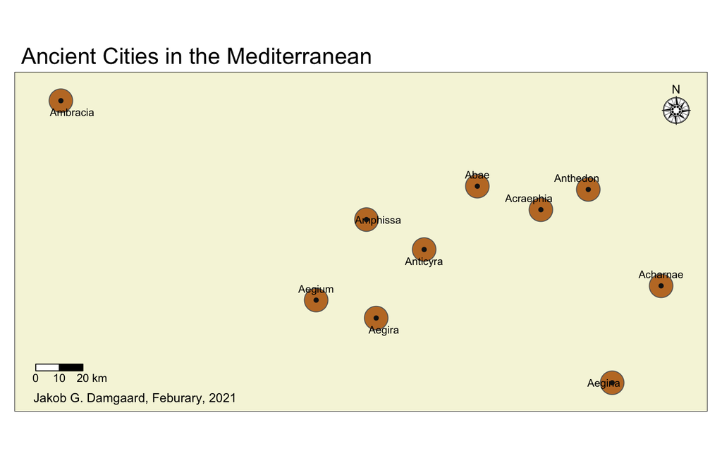

```r
# Grab the first 10 elements in the sf object and the buffer
ten_buffers <- cities_5km %>% slice(1:10)
ten_cities <- cities_sf3035 %>% slice(1:10)

# Create a quick tmap
library(tmap)
current.mode <- tmap_mode("plot")

buffer_plot <- tm_shape(ten_buffers)  +
  tm_polygons(col = "#C17A2E") +
  tm_shape(ten_cities) +
  tm_text("Ancient Toponym", size = 0.7, auto.placement = 5
          ) +
  tm_dots(col = "#171514",
             size = 0.1) +
  tm_scale_bar(breaks = c(0,10,20),
               text.size = 0.75,
               position = c(0.024, 0.06)) +
  tm_compass(position = c("right", "top"),
             type = "rose",
             size = 2) +
  tm_credits(text = "Jakob G. Damgaard, Feburary, 2021",
             position = c(0.022, 0.01),
              size = 0.83) +
  tm_layout(main.title = "Ancient Cities in the Mediterranean",
            bg.color = "beige",
            inner.margins = c(0.05, 0.05, 0.05, 0.05))

# Plot da plot
buffer_plot # Everything works
```

If all went well, you should see a map, where the diameter of each city buffer corresponds to the 10km notch on the scale

# Task 4: Download ancient inscriptions and wrangle coordinates into shape

Let’s now look at some data that spatially co-occurs with these ancient places. Below is a link to an online dataset from the Epigraphic Database of Heidelberg of ancient inscriptions from one part of the ancient world. These inscriptions combine private and official expressions dedicated for personal reasons (death of a dear person) or public (dedication of a major building, placement of milestone, etc.).

The json dataset is hefty with some 12 thousand inscriptions and 74 variables. Coordinates are nested in a single column and may need wrangling. Do tasks deliberately in small steps after you test on subsets lest you overwhelm your R.

- Download the linked file with `download.file()` where you can find it.
- The inscriptions dataset is in `.json` format, which is becoming the dominant format for sharing data online. Use the `jsonlite::fromJSON` function in the library to load it back into R
- Next, use `as_tibble()` to convert into rectangular format.
- Check the column names looking for something that holds spatial data. There should be a `coordinates` column. Look at the column whether it holds meaningful coordinates.
- Separate the two values inside single coordinate column and create a separate longitude and a latitude column, which contain clean decimal numbers. You will need to clean up non-numeric characters en route. Make sure to keep the decimal point. Hint: there are lots of ways of getting clean decimal coordinates into two new columns, so feel free to diverge from the suggested course. Check out the `gsub()`, `grep()` and `str_extract()` functions to implement regular expressions in tidyverse pipeline.

```r
# Libraries
library(tidyverse)
library(jsonlite)
library(tidytext)

# Download the file and save as inscriptions.json (consider commenting out after you first run to avoid repeat downloading)
download.file("https://sciencedata.dk/public/b6b6afdb969d378b70929e86e58ad975/EDH_subset_2021-02-15.json", "data/inscriptions.json")

# Load it into R from wherever you put it, and convert into a tibble
list_json <- jsonlite::fromJSON("data/inscriptions.json")
inscriptions = as_tibble(list_json)

# Check the first couple lines and column names
head(inscriptions)
```

```
# A tibble: 6 x 74
  responsible_ind… type_of_inscrip… letter_size not_after literature work_status
  <chr>            <chr>            <chr>       <chr>     <chr>      <chr>
1 Feraudi          epitaph          3.2-2 cm    0130      AE 1983, … provisional
2 Feraudi          epitaph          4 cm        0200      AE 1983, … no image
3 Feraudi          epitaph          <NA>        0200      AE 1983, … no image
4 Feraudi          epitaph          9 cm        -0051     AE 1983, … checked wi…
5 Feraudi          epitaph          4-2 cm      0200      AE 1983, … provisional
6 Gräf             epitaph          4.2-2.5 cm  0200      AE 1983, … checked wi…
# … with 68 more variables: height <chr>, diplomatic_text <chr>, people <list>,
#   depth <chr>, material <chr>, type_of_monument <chr>, province_label <chr>,
#   width <chr>, transcription <chr>, country <chr>, uri <chr>,
#   findspot_ancient <chr>, last_update <chr>, modern_region <chr>,
#   findspot_modern <chr>, language <chr>, id <chr>, edh_geography_uri <chr>,
#   commentary <chr>, trismegistos_uri <chr>, not_before <chr>,
#   external_image_uris <list>, fotos <list>, coordinates <list>,
#   idno_tm <chr>, placenames_refs <list>, text_edition <chr>,
#   origdate_text <chr>, layout_execution <chr>, layout_execution_text <chr>,
#   support_objecttype <chr>, support_objecttype_text <chr>,
#   support_material <chr>, support_material_text <chr>,
#   support_decoration <chr>, keywords_term <chr>, keywords_term_text <chr>,
#   type_of_inscription_clean <chr>, type_of_inscription_certainty <chr>,
#   height_cm <dbl>, width_cm <dbl>, depth_cm <dbl>, material_clean <chr>,
#   type_of_monument_clean <chr>, type_of_monument_certainty <chr>,
#   province_label_clean <chr>, province_label_certainty <chr>,
#   country_clean <chr>, country_certainty <chr>, findspot_ancient_clean <chr>,
#   findspot_ancient_certainty <chr>, modern_region_clean <chr>,
#   modern_region_certainty <chr>, findspot_modern_clean <chr>,
#   findspot_modern_certainty <chr>, findspot_clean <chr>,
#   findspot_certainty <chr>, origdate_text_clean <chr>,
#   clean_text_conservative <chr>, clean_text_interpretive_word <chr>,
#   clean_text_interpretive_sentence <chr>, findspot <chr>, year_of_find <chr>,
#   present_location <chr>, geography <chr>,
#   social_economic_legal_history <chr>, religion <chr>, military <chr>
```

```r
colnames(inscriptions)
```

```
 [1] "responsible_individual"           "type_of_inscription"
 [3] "letter_size"                      "not_after"
 [5] "literature"                       "work_status"
 [7] "height"                           "diplomatic_text"
 [9] "people"                           "depth"
[11] "material"                         "type_of_monument"
[13] "province_label"                   "width"
[15] "transcription"                    "country"
[17] "uri"                              "findspot_ancient"
[19] "last_update"                      "modern_region"
[21] "findspot_modern"                  "language"
[23] "id"                               "edh_geography_uri"
[25] "commentary"                       "trismegistos_uri"
[27] "not_before"                       "external_image_uris"
[29] "fotos"                            "coordinates"
```

[output cut: 22 more lines]

```r
head(inscriptions$coordinates) # This column appears to hold meaningful coordinates
```

```
[[1]]
[1] 14.0551 40.8472

[[2]]
[1] 12.4823 41.8955

[[3]]
[1] 12.4823 41.8955

[[4]]
[1] 12.4823 41.8955

[[5]]
[1] 12.4823 41.8955

[[6]]
[1] 12.5632 44.0590
```

```r
# Wrangle the coordinates into a plottable format
i_sm <- inscriptions %>%
  slice(1:100) %>%
  filter(coordinates != "list()") %>% # Removing rows with missing coordinates
  mutate(coordinates, sapply(coordinates, toString)) # Convert lists into strings

# Remove unwanted characters
i_sm$coordinates <- gsub("[c()]", "", i_sm$coordinates)

# Seperating 'coordinates' column by comma into two columns
i_sm <- i_sm %>%
  separate(col = coordinates, into = c("longitude","latitude"), sep = ",") %>%
  mutate(longitude = as.numeric(longitude),
         latitude = as.numeric(latitude))

# Check to see if it works
head(i_sm$latitude)
```

```
[1] 40.8472 41.8955 41.8955 41.8955 41.8955 44.0590
```

```r
head(i_sm$longitude)
```

```
[1] 14.0551 12.4823 12.4823 12.4823 12.4823 12.5632
```

```r
# Check the result of the subset, does the location look reasonable?
leaflet() %>% addTiles() %>% addMarkers(lng=i_sm$longitude,lat=i_sm$latitude)
```

[interactive chart not shown]

Oooof. That was some serious wrangling!

### Question 2:

*Which part of the world are the inscriptions from?* The inscriptions are located in modern day Italy (at least the first 97 inscriptions) .

# Task 5: Convert inscriptions into an sf object

Now that the hard work is done, let’s apply the wrangling to the full dataset and clean up the missing coordinates and outlier values.

- Not all coordinates are complete. Remove the rows with missing latitude or longitude
- Some incorrect points have sneaked in! Eliminate data with longitude smaller than 5 and larger than 20 degrees.
- Make the resulting `inscriptions` tibble into an sf object using the newly created and cleaned longitude and latitude column in the `coords` argument. The CRS of the data is 4326.
- Plot your data using st_geometry()

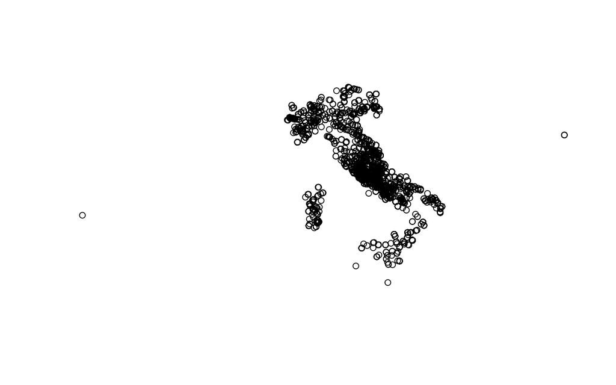

```r
# Applying code from former chunch to all the data
i <- inscriptions %>%
  filter(coordinates != "list()") %>% # Removing rows with missing coordinates
  mutate(coordinates, sapply(coordinates, toString))

# Remove unwanted characters
i$coordinates <- gsub("[c()]", "", i$coordinates)


# Seperating 'coordinates' column by comma into two columns
i <- i %>%
  separate(col = coordinates, into = c("longitude","latitude"), sep = ",") %>%
  mutate(longitude = as.numeric(longitude),
         latitude = as.numeric(latitude)) %>%
  filter(longitude > 5 && longitude < 20)


# Create a sf object
insc_sf4326 <- st_as_sf(i, coords = c("longitude", "latitude"), crs = 4326)

# Plot
plot(st_geometry(insc_sf4326))
```